# Презентация по разделу №2 дополнительного курса

## Задание 15

Формулировка задания №15 (рис. 29).

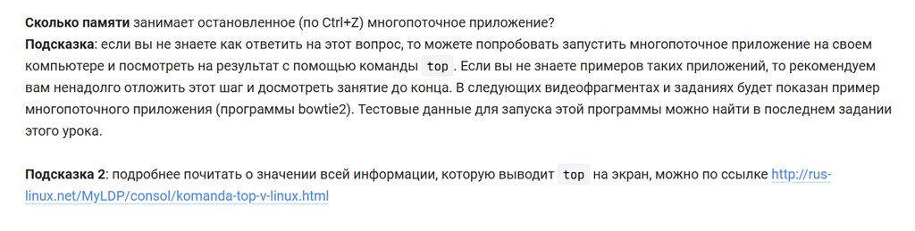

Рисунок 29: Задание №15

## Задание 15

Решение задания №15 (рис. 30).

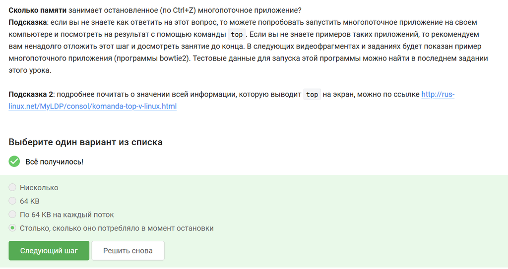

Рисунок 30: Решение №15

## Задание 16

Формулировка задания №16 (рис. 31).

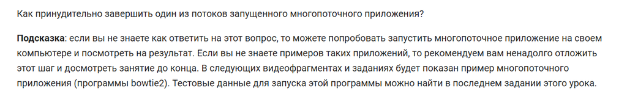

Рисунок 31: Задание №16

## Задание 16

Решение задания №16 (рис. 32).

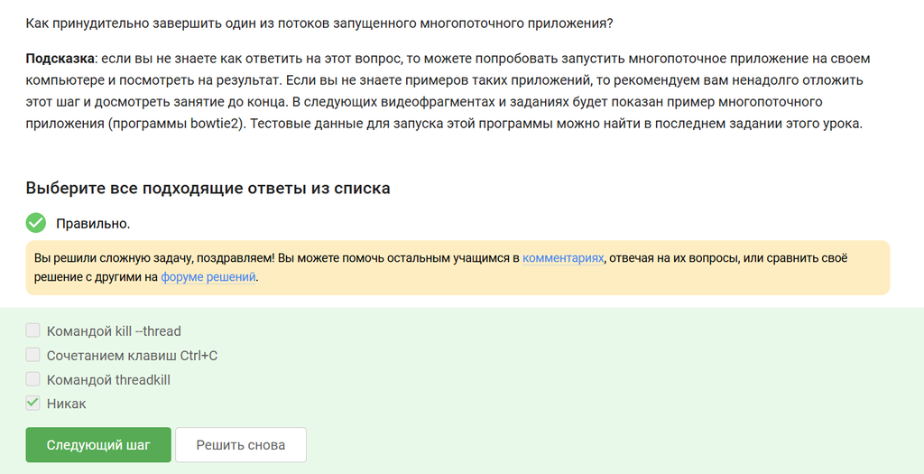

Рисунок 32: Решение №16

## Задание 17

Формулировка задания №17 (рис. 33).

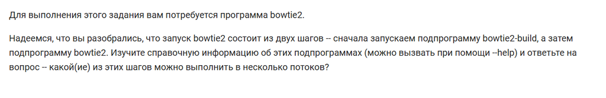

Рисунок 33: Задание №17

## Задание 17

Решение задания №17, bowtie2-build, так скажем, единый процесс, который нельзя разбить на несколько параллельных процессов (рис. 34).

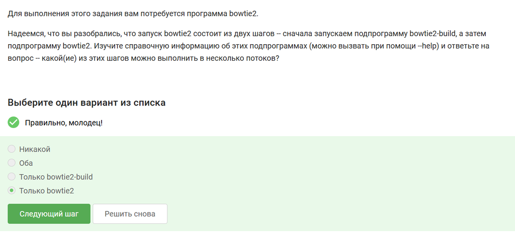

Рисунок 34: Решение №17

## Задание 18

Формулировка задания №18 (рис. 35).

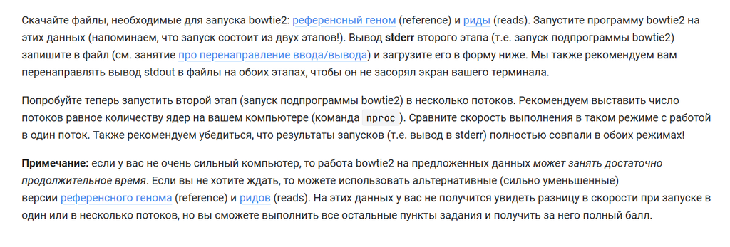

Рисунок 35: Задание №18

## Задание 18

Решение задания №18: sudo bowtie2-build reference.fasta reference_index; sudo bowtie2 -x reference_index -U reads.fastq.gz -S aligned_reads.sam 2> bowtie2_stderr.log (рис. 36).

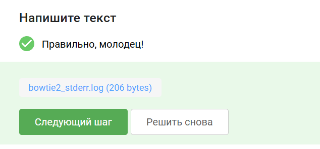

Рисунок 36: Решение №18

## Задание 19

Формулировка задания №19 (рис. 37).

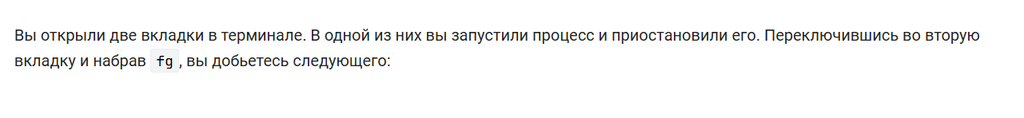

Рисунок 37: Задание №19

## Задание 19

Решение задания №19, сам по себе терминал не видит запущенный процесс в другом терминале (рис. 38).

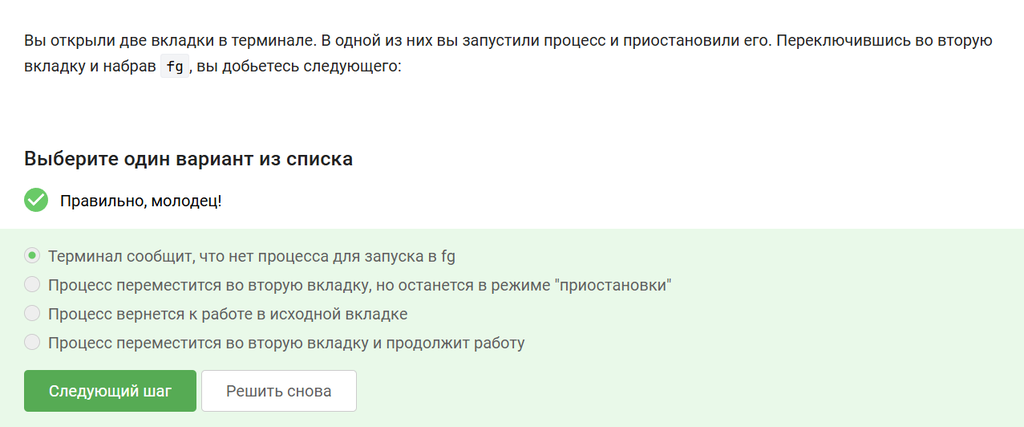

Рисунок 38: Решение №19

## Задание 20

Формулировка задания №20 (рис. 39).

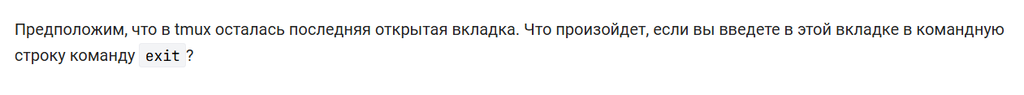

Рисунок 39: Задание №20

## Задание 20

Решение задания №20 (рис. 40).

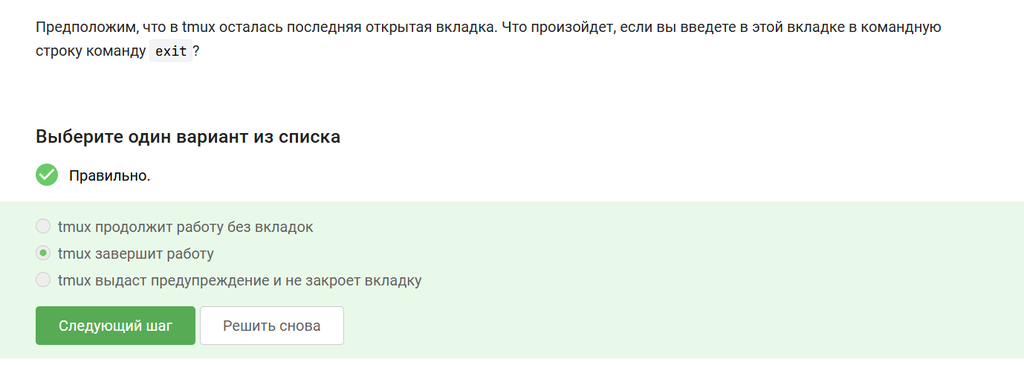

Рисунок 40: Решение №20

## Задание 21

Формулировка задания №21 (рис. 41).

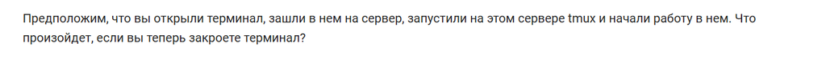

Рисунок 41: Задание №21

## Задание 21

Решение задания №21 (рис. 42).

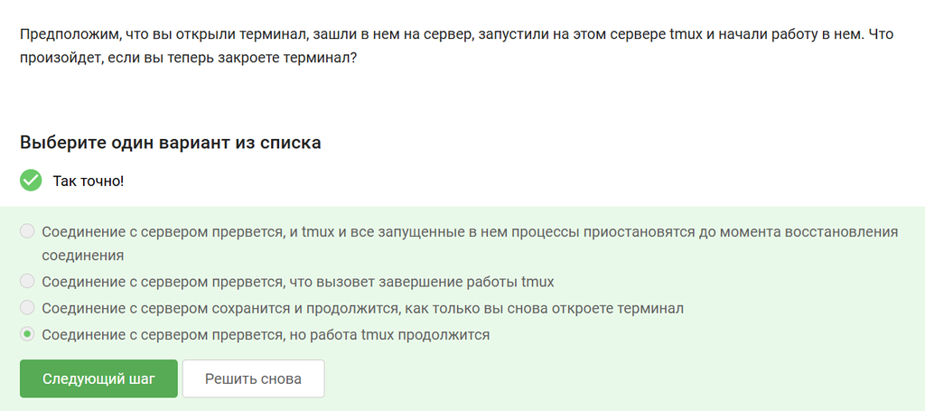

Рисунок 42: Решение №21

## Задание 22

Формулировка задания №22 (рис. 43).

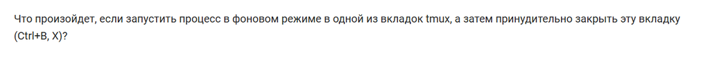

Рисунок 43: Задание №22

## Задание 22

Решение задания №22 (рис. 44).

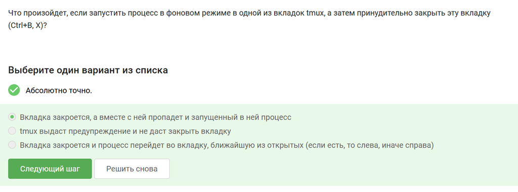

Рисунок 44: Решение №22

## Задание 23

Формулировка задания №23 (рис. 45).

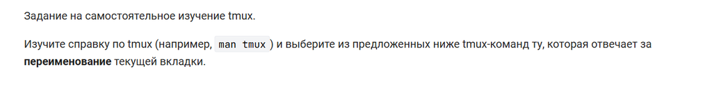

Рисунок 45: Задание №23

## Задание 23

Решение задания №23 (рис. 46).

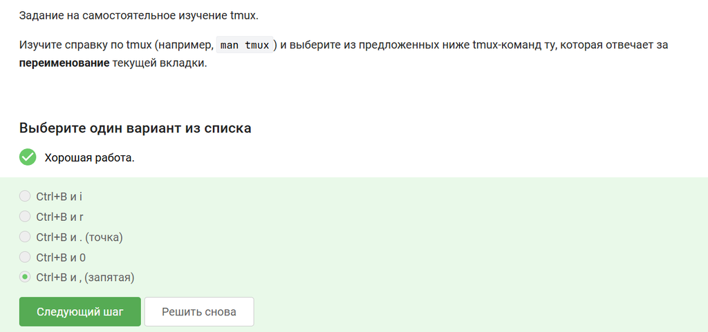

Рисунок 46: Решение №23

## Задание 24

Формулировка задания №24 (рис. 47).

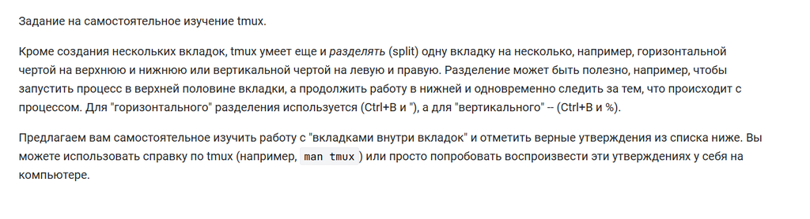

Рисунок 47: Задание №24

## Задание 24

Решение задания №24, 2-ое неверно, тк закроется только часть вкладки (рис. 48).

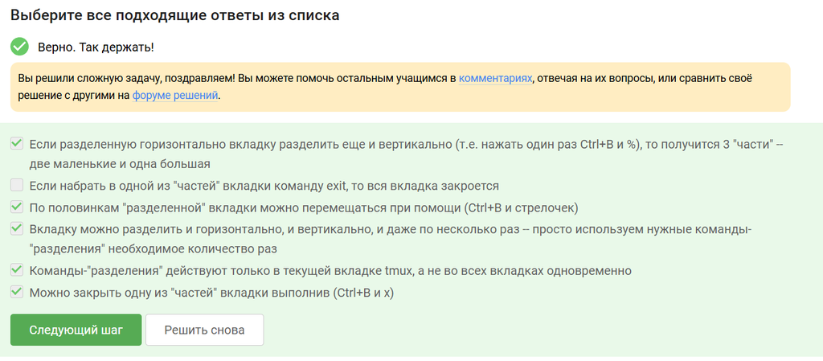

Рисунок 48: Решение №24

# Выводы

## Выводы

В процессе проделанной работы я приобрёл практические навыки работы с Linux и прошёл 2-ой раздел курса “Введение в Linux” на Stepik.